# 比较不同的对单细胞转录组数据聚类的方法

jmzeng@163.com

10/12/2017

# 背景介绍

聚类之前必须要对表达矩阵进行normalization，而且要去除一些批次效应等外部因素。通过对表达矩阵的聚类，可以把细胞群体分成不同的状态，解释为什么会有不同的群体。不过从计算的角度来说，聚类还是蛮复杂的，各个细胞并没有预先标记好，而且也没办法事先知道可以聚多少类。尤其是在单细胞转录组数据里面有很高的噪音，基因非常多，意味着的维度很高。

对这样的高维数据，需要首先进行降维，可以选择PCA或者t-SNE方法。聚类的话，一般都是无监督聚类方法，比如：hierarchical clustering, k-means clustering and graph-based clustering。算法略微有一点复杂，略过吧。

这里主要比较6个常见的单细胞转录组数据的聚类包：

- [SINCERA](https://research.cchmc.org/pbge/sincera.html)
- pcaReduce
- [SC3](http://bioconductor.org/packages/SC3/)
- tSNE + k-means
- [SEURAT](https://github.com/satijalab/seurat)
- [SNN-Cliq](http://bioinfo.uncc.edu/SNNCliq/)

所以需要安装并且加载一些包,安装代码如下；

```r
install.packages('pcaReduce')
## try http:// if https:// URLs are not supported
source("https://bioconductor.org/biocLite.R")
biocLite("SC3")
biocLite("Seurat")
install.packages("devtools")
library("devtools")
install_github("BPSC","nghiavtr")
install_github("hemberg-lab/scRNA.seq.funcs")
devtools::install_github("JustinaZ/pcaReduce")
```

加载代码如下：

```r
library(pcaMethods)
library(pcaReduce)
library(SC3)
library(scater)
library(pheatmap)
set.seed(1234567)
```

# 加载测试数据

这里选取的是数据，加载了这个scater包的SCESet对象，包含着一个23730 features, 301 samples 的表达矩阵。

供11已知的种细胞类型，这样聚类的时候就可以跟这个已知信息做对比，看看聚类效果如何。

可以直接用plotPCA来简单PCA并且可视化。

```r
pollen <- readRDS("../pollen/pollen.rds")
pollen
```

```
## SCESet (storageMode: lockedEnvironment)
## assayData: 23730 features, 301 samples
##   element names: exprs, is_exprs, tpm
## protocolData: none
## phenoData
##   rowNames: Hi_2338_1 Hi_2338_2 ... Hi_GW16_26 (301 total)
##   varLabels: cell_type1 cell_type2 ... is_cell_control (33 total)
##   varMetadata: labelDescription
## featureData
##   featureNames: A1BG A1BG-AS1 ... ZZZ3 (23730 total)
##   fvarLabels: mean_exprs exprs_rank ... feature_symbol (11 total)
##   fvarMetadata: labelDescription
## experimentData: use 'experimentData(object)'
## Annotation:
```

```r
head(fData(pollen))
```

```
##          mean_exprs exprs_rank n_cells_exprs total_feature_exprs
## A1BG     0.56418762      12460            79           169.82048
## A1BG-AS1 0.31265010      10621            37            94.10768
## A1CF     0.05453986       6796            59            16.41650
## A2LD1    0.22572953       9781            28            67.94459
## A2M      0.15087563       8855            21            45.41356
## A2M-AS1  0.02428046       5366             3             7.30842
##          pct_total_exprs pct_dropout total_feature_tpm
## A1BG        1.841606e-03    73.75415            481.37
## A1BG-AS1    1.020544e-03    87.70764            538.18
## A1CF        1.780276e-04    80.39867             13.99
## A2LD1       7.368203e-04    90.69767            350.65
## A2M         4.924842e-04    93.02326           1356.63
## A2M-AS1     7.925564e-05    99.00332             88.61
##          log10_total_feature_tpm pct_total_tpm is_feature_control
## A1BG                    2.683380  1.599256e-04              FALSE
## A1BG-AS1                2.731734  1.787996e-04              FALSE
## A1CF                    1.175802  4.647900e-06              FALSE
## A2LD1                   2.546111  1.164965e-04              FALSE
## A2M                     3.132781  4.507134e-04              FALSE
## A2M-AS1                 1.952356  2.943891e-05              FALSE
##          feature_symbol
## A1BG               A1BG
## A1BG-AS1       A1BG-AS1
## A1CF               A1CF
## A2LD1             A2LD1
## A2M                 A2M
## A2M-AS1         A2M-AS1
```

```r
table(pData(pollen)$cell_type1)
```

```
##
##   2338   2339     BJ   GW16   GW21 GW21+3  hiPSC   HL60   K562   Kera
##     22     17     37     26      7     17     24     54     42     40
##    NPC
##     15
```

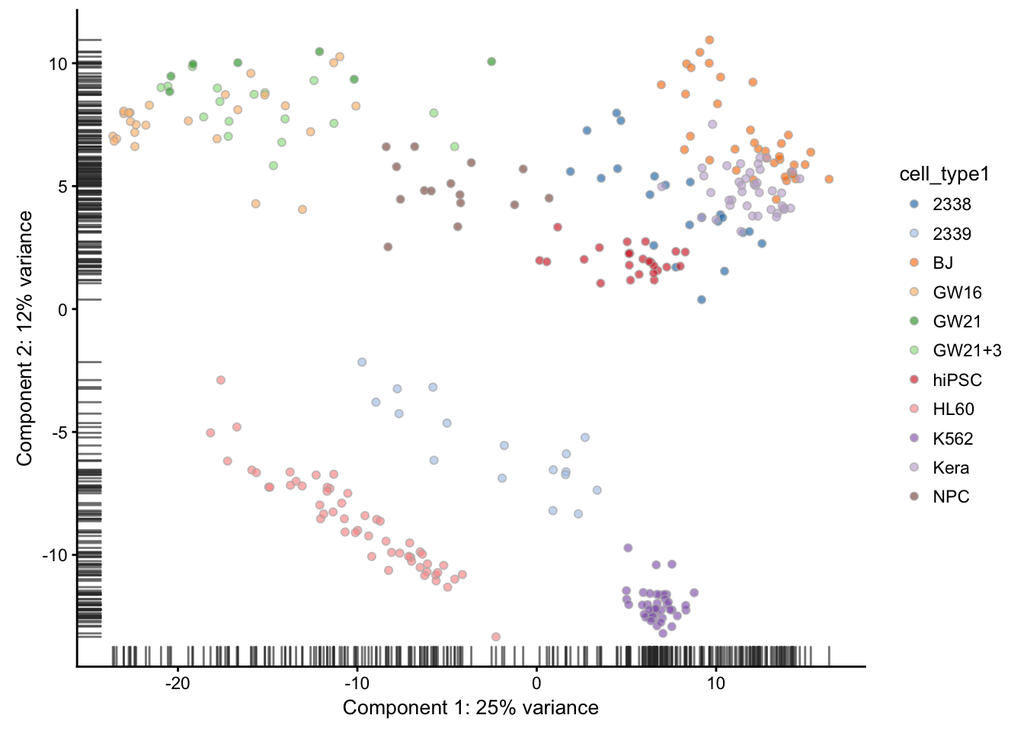

```r
plotPCA(pollen, colour_by = "cell_type1")
```

可以看到简单的PCA也是可以区分部分细胞类型的，只不过在某些细胞相似性很高的群体区分力度不够，所以需要开发新的算法来解决这个聚类的问题。

# SC聚类

```r
pollen <- sc3_prepare(pollen, ks = 2:5)
pollen <- sc3_estimate_k(pollen)
pollen@sc3$k_estimation
```

```
## [1] 11
```

```r
## 准备 SCESet对象 数据给 SC3方法，先预测能聚多少个类，发现恰好是11个。

## 这里是并行计算，所以速度还可以
pollen <- sc3(pollen, ks = 11, biology = TRUE)
```

```r
pollen
```

```
## SCESet (storageMode: lockedEnvironment)
## assayData: 23730 features, 301 samples
##   element names: exprs, is_exprs, tpm
## protocolData: none
## phenoData
##   rowNames: Hi_2338_1 Hi_2338_2 ... Hi_GW16_26 (301 total)
##   varLabels: cell_type1 cell_type2 ... sc3_11_log2_outlier_score
##     (35 total)
##   varMetadata: labelDescription
## featureData
##   featureNames: A1BG A1BG-AS1 ... ZZZ3 (23730 total)
##   fvarLabels: mean_exprs exprs_rank ... sc3_11_de_padj (16 total)
##   fvarMetadata: labelDescription
## experimentData: use 'experimentData(object)'
## Annotation:
```

```r
head(fData(pollen))
```

```
##          mean_exprs exprs_rank n_cells_exprs total_feature_exprs
## A1BG     0.56418762      12460            79           169.82048
## A1BG-AS1 0.31265010      10621            37            94.10768
## A1CF     0.05453986       6796            59            16.41650
## A2LD1    0.22572953       9781            28            67.94459
## A2M      0.15087563       8855            21            45.41356
## A2M-AS1  0.02428046       5366             3             7.30842
##          pct_total_exprs pct_dropout total_feature_tpm
## A1BG        1.841606e-03    73.75415            481.37
## A1BG-AS1    1.020544e-03    87.70764            538.18
## A1CF        1.780276e-04    80.39867             13.99
## A2LD1       7.368203e-04    90.69767            350.65
## A2M         4.924842e-04    93.02326           1356.63
## A2M-AS1     7.925564e-05    99.00332             88.61
##          log10_total_feature_tpm pct_total_tpm is_feature_control
## A1BG                    2.683380  1.599256e-04              FALSE
## A1BG-AS1                2.731734  1.787996e-04              FALSE
## A1CF                    1.175802  4.647900e-06              FALSE
## A2LD1                   2.546111  1.164965e-04              FALSE
## A2M                     3.132781  4.507134e-04              FALSE
## A2M-AS1                 1.952356  2.943891e-05              FALSE
##          feature_symbol sc3_gene_filter sc3_11_markers_clusts
## A1BG               A1BG            TRUE                     5
## A1BG-AS1       A1BG-AS1            TRUE                     4
## A1CF               A1CF            TRUE                     2
## A2LD1             A2LD1           FALSE                    NA
## A2M                 A2M           FALSE                    NA
## A2M-AS1         A2M-AS1           FALSE                    NA
##          sc3_11_markers_padj sc3_11_markers_auroc sc3_11_de_padj
## A1BG            7.740802e-10            0.8554452   1.648352e-18
## A1BG-AS1        1.120284e-03            0.6507985   5.575777e-03
## A1CF            5.007946e-23            0.8592113   1.162843e-17
## A2LD1                     NA                   NA             NA
## A2M                       NA                   NA             NA
## A2M-AS1                   NA                   NA             NA
```

```r
## 可以看到SC3方法处理后的SCESet对象的基因信息增加了5列，比较重要的是sc3_gene_filter信息，决定着该基因是否拿去聚类，因为基因太多了，需要挑选
table(fData(pollen)$sc3_gene_filter)
```

```
##
## FALSE  TRUE
## 11902 11828
```

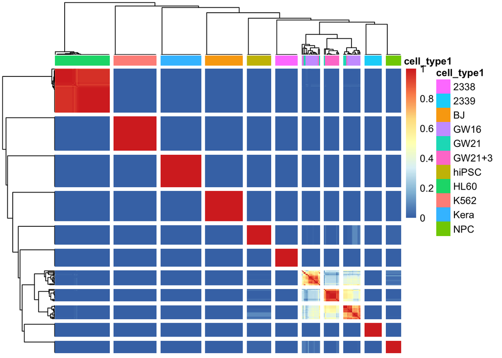

```r
### 只有一半的基因被挑选去聚类了

## 后面是一些可视化
sc3_plot_consensus(pollen, k = 11, show_pdata = "cell_type1")
```

[figure not shown]

```r
sc3_plot_silhouette(pollen, k = 11)
```

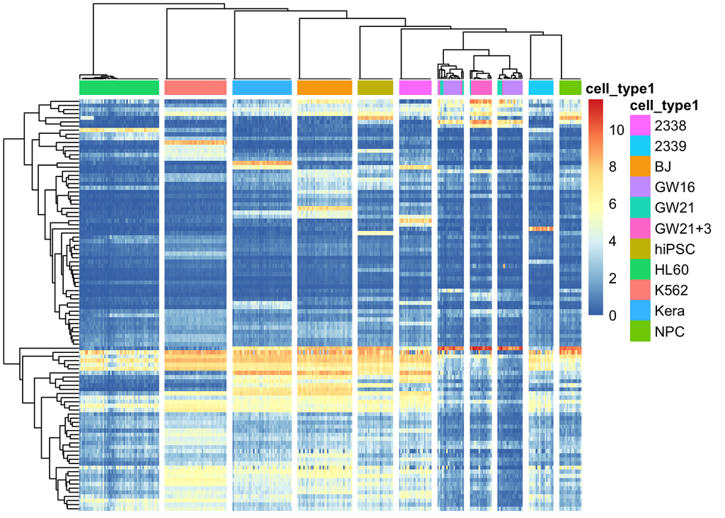

```r
sc3_plot_expression(pollen, k = 11, show_pdata = "cell_type1")
```

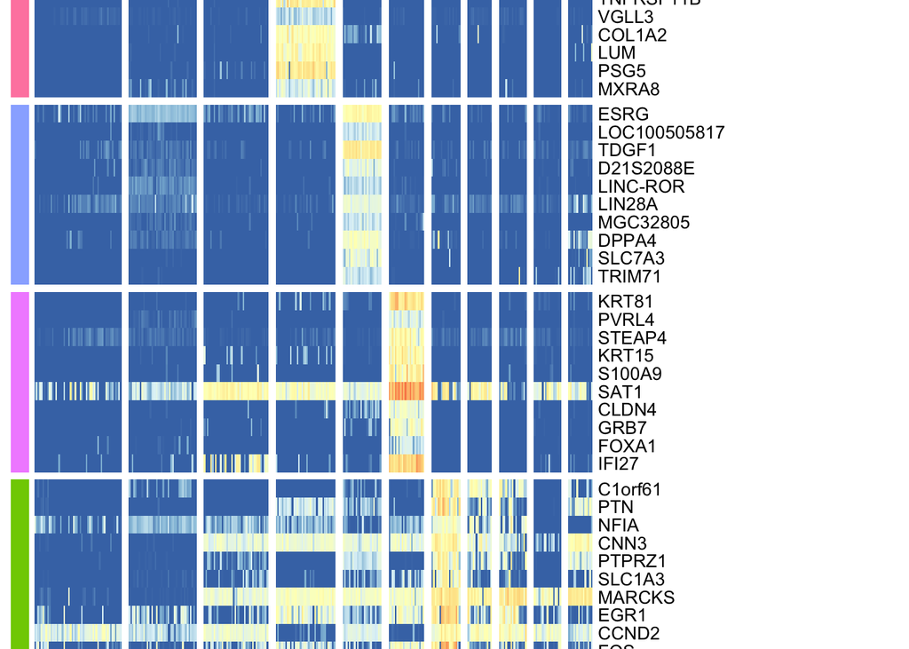

```r
sc3_plot_markers(pollen, k = 11, show_pdata = "cell_type1")
```

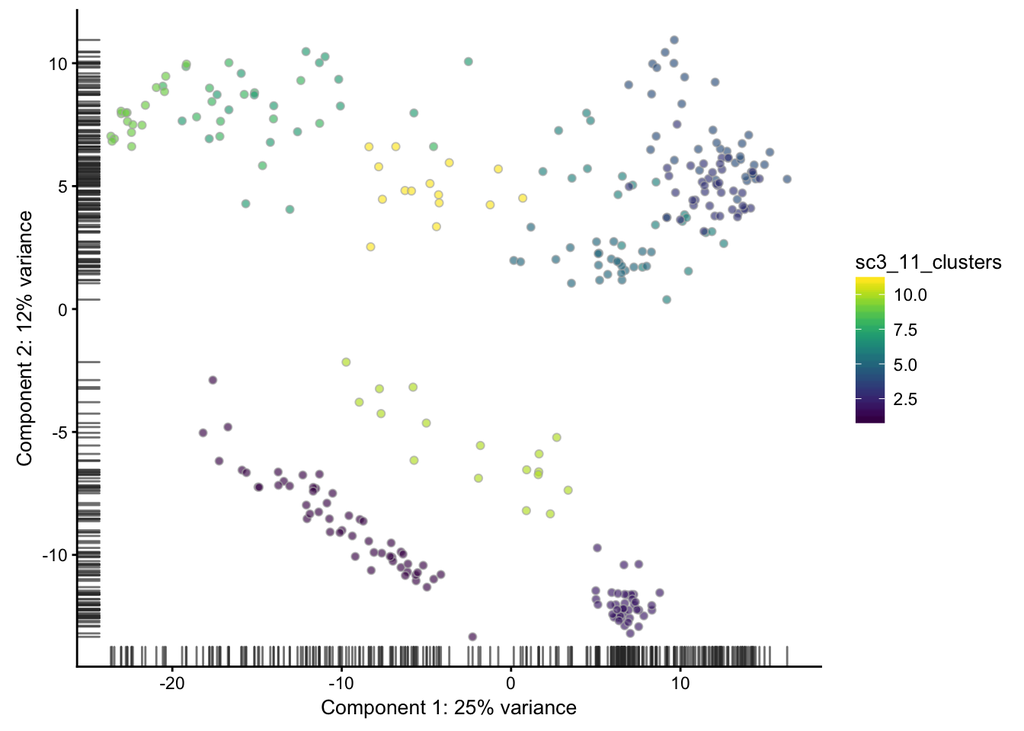

```r
plotPCA(pollen, colour_by = "sc3_11_clusters")
```

```r
## 还支持shiny的交互式聚类，暂时不显示
# sc3_interactive(pollen)
```

很明显可以看到SC3聚类的效果要好于普通的PCA

# pcaReduce

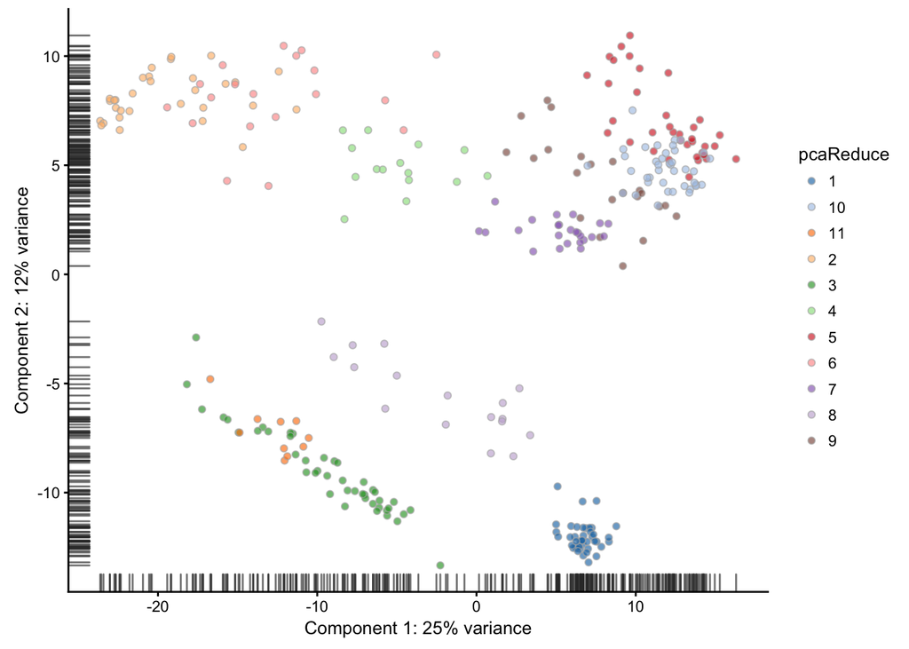

```r
# use the same gene filter as in SC3
input <- exprs(pollen[fData(pollen)$sc3_gene_filter, ])

# run pcaReduce 1 time creating hierarchies from 1 to 30 clusters
pca.red <- PCAreduce(t(input), nbt = 1, q = 30, method = 'S')[[1]]
##  这里对2~30种类别的情况都分别对样本进行分组。

## 我们这里取只有11组的时候，这些样本是如何分组的信息来可视化。
pData(pollen)$pcaReduce <- as.character(pca.red[,32 - 11])
plotPCA(pollen, colour_by = "pcaReduce")
```

# tSNE + kmeans

scater包包装了 [Rtsne](https://cran.r-project.org/web/packages/Rtsne/index.html) 和 [ggplot2](https://cran.r-project.org/web/packages/ggplot2/index.html) 来做tSNE并且可视化。

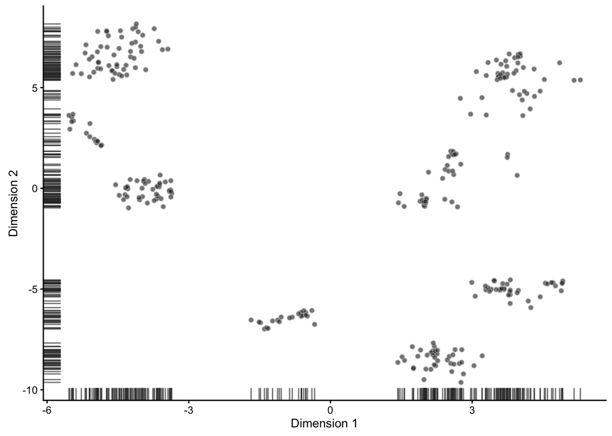

```r
pollen <- plotTSNE(pollen, rand_seed = 1, return_SCESet = TRUE)
```

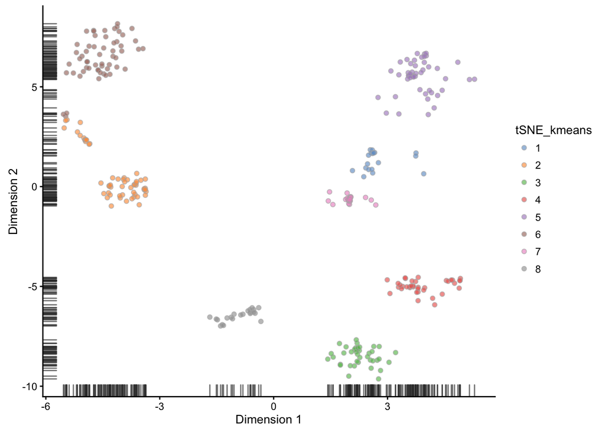

```r
## 上面的tSNE的结果，下面用kmeans的方法进行聚类，假定是8类细胞类型。
pData(pollen)$tSNE_kmeans <- as.character(kmeans(pollen@reducedDimension, centers = 8)$clust)
plotTSNE(pollen, rand_seed = 1, colour_by = "tSNE_kmeans")
```

# SNN-Cliq

```r
distan <- "euclidean"
par.k <- 3
par.r <- 0.7
par.m <- 0.5
# construct a graph
scRNA.seq.funcs::SNN(
    data = t(input),
    outfile = "snn-cliq.txt",
    k = par.k,
    distance = distan
)
# find clusters in the graph
snn.res <-
    system(
        paste0(
            "python snn-cliq/Cliq.py ",
            "-i snn-cliq.txt ",
            "-o res-snn-cliq.txt ",
            "-r ", par.r,
            " -m ", par.m
        ),
        intern = TRUE
    )
cat(paste(snn.res, collapse = "\n"))

snn.res <- read.table("res-snn-cliq.txt")
# remove files that were created during the analysis
system("rm snn-cliq.txt res-snn-cliq.txt")

pData(pollen)$SNNCliq <- as.character(snn.res[,1])
plotPCA(pollen, colour_by = "SNNCliq")
```

[output not shown]

# SINCERA

```r
# perform gene-by-gene per-sample z-score transformation
dat <- apply(input, 1, function(y) scRNA.seq.funcs::z.transform.helper(y))
# hierarchical clustering
dd <- as.dist((1 - cor(t(dat), method = "pearson"))/2)
hc <- hclust(dd, method = "average")

num.singleton <- 0
kk <- 1
for (i in 2:dim(dat)[2]) {
    clusters <- cutree(hc, k = i)
    clustersizes <- as.data.frame(table(clusters))
    singleton.clusters <- which(clustersizes$Freq < 2)
    if (length(singleton.clusters) <= num.singleton) {
        kk <- i
    } else {
        break;
    }
}
cat(kk)
```

```
## 14
```

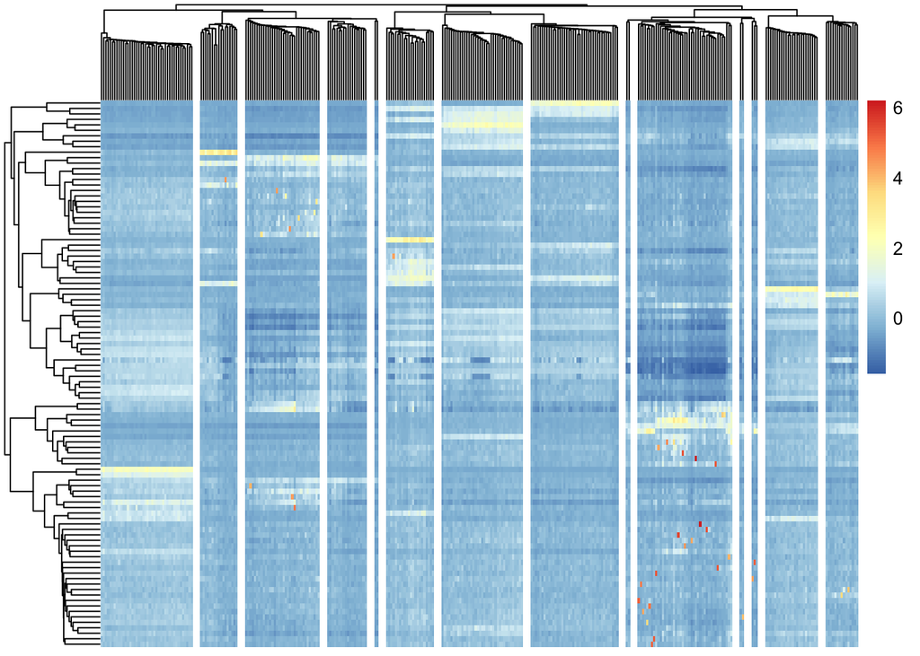

```r
pheatmap(
    t(dat),
    cluster_cols = hc,
    cutree_cols = 14,
    kmeans_k = 100,
    show_rownames = FALSE
)
```

# SEURAT

```r
library(Seurat)
pollen_seurat <- new("seurat", raw.data = get_exprs(pollen, exprs_values = "tpm"))
pollen_seurat <- Setup(pollen_seurat, project = "Pollen")
pollen_seurat <- MeanVarPlot(pollen_seurat)
pollen_seurat <- RegressOut(pollen_seurat, latent.vars = c("nUMI"),
                            genes.regress = pollen_seurat@var.genes)
pollen_seurat <- PCAFast(pollen_seurat)
pollen_seurat <- RunTSNE(pollen_seurat)
pollen_seurat <- FindClusters(pollen_seurat)
TSNEPlot(pollen_seurat, do.label = T)
```

[output not shown]

```r
pData(pollen)$SEURAT <- as.character(pollen_seurat@ident)
sc3_plot_expression(pollen, k = 11, show_pdata = "SEURAT")
markers <- FindMarkers(pollen_seurat, 2)
FeaturePlot(pollen_seurat,
            head(rownames(markers)),
            cols.use = c("lightgrey", "blue"),
            nCol = 3)
```

[output not shown]